# Crecimiento y nutrición en pejerrey

Fabián Canosa

18 May 2022

## **Análisis Exploratorio de datos de la db Datos Pejerrey.xlsx**

### Condiciones del *feeding trial*

Pejerreyes juveniles de dos meses post eclosión se distrubuyeron aleatoriamente en 12 tanques de 300L con flujo abierto de agua y aireación. Los tratamientos fueron: dietas D1: 40P-12L, D2: 50P-12L, D3: 40P-20L y D4: 50P-20L.

### Asignación de dietas a cada tanque:

| Dieta | Tanque |
| --- | --- |
| D1 | T1, T5, T9 |
| D2 | T2, T6, T10 |
| D3 | T3, T7, T11 |
| D4 | T4, T8, T12 |

```r
Growth <- read_excel("Datos pejerrey.xlsx", sheet = 2, na="NA")
Growth$Fecha<-as.Date(Growth$Fecha, "%d-%m-%y")# se transforma characte como fecha
Growth$Tanque<-as.factor(Growth$Tanque)
Growth$Dieta<-as.factor(Growth$Dieta)
Growth<-Growth%>%mutate(Dias=(Fecha[1:60]-Fecha [1]+1)) #genera la variable Dias restando las fechas de los muestreos
Growth$Dias<-as.factor(Growth$Dias)
str(Growth)
```

```
## tibble [60 × 6] (S3: tbl_df/tbl/data.frame)
##  $ Fecha  : Date[1:60], format: "2020-10-26" "2020-10-26" ...
##  $ Tanque : Factor w/ 12 levels "1","2","3","4",..: 1 2 3 4 5 6 7 8 9 10 ...
##  $ Dieta  : Factor w/ 4 levels "D1","D2","D3",..: 1 2 3 4 1 2 3 4 1 2 ...
##  $ N      : num [1:60] 79 79 79 79 79 79 79 79 79 79 ...
##  $ Biomasa: num [1:60] 0.839 0.85 0.947 0.913 0.9 0.879 0.774 0.93 0.863 0.9 ...
##  $ Dias   : Factor w/ 5 levels "1","15","29",..: 1 1 1 1 1 1 1 1 1 1 ...
```

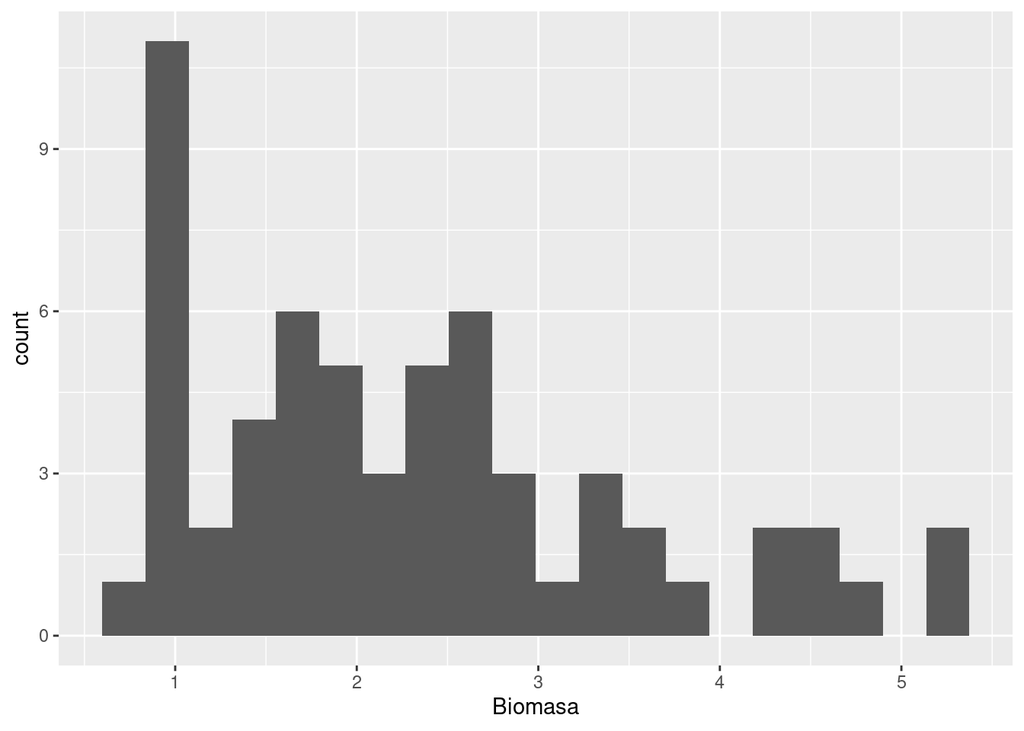

```r
ggplot(Growth, aes(Biomasa ))+
  geom_histogram (bins = 20)
```

Dado el histograma obtenido, los datos no parecen seguir una distribución normal. Es posible que sean pocos datos como para ver bien la distribución normal. Habrá que estudiar si se cumple con el supuesto de normalidad

```r
table(Growth$Tanque, Growth$Dieta)
```

```
##
##      D1 D2 D3 D4
##   1   5  0  0  0
##   2   0  5  0  0
##   3   0  0  5  0
##   4   0  0  0  5
##   5   5  0  0  0
##   6   0  5  0  0
##   7   0  0  5  0
##   8   0  0  0  5
##   9   5  0  0  0
##   10  0  5  0  0
##   11  0  0  5  0
##   12  0  0  0  5
```

Los datos están balanceados ya que hay la misma cantidad de observaciones en cada grupo.

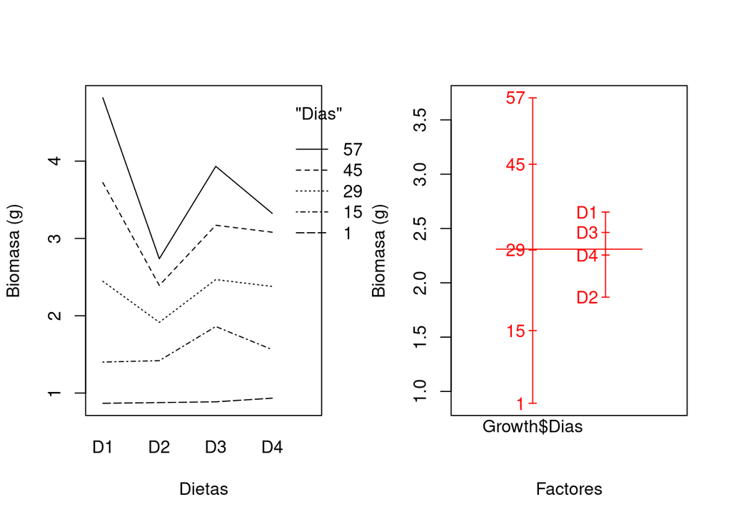

```r
par(mfrow = c(1, 2))
interaction.plot(Growth$Dieta, Growth$Dias, Growth$Biomasa, fun=mean, trace.label = deparse1("Dias"), xlab="Dietas", ylab="Biomasa (g)")

plot.design(Growth$Biomasa ~ Growth$Dias + Growth$Dieta, col="red",ylab = "Biomasa (g)", xlab = "Factores")
```

```r
par(mfrow = c(1, 1))
```

Estos gráficos muestran que la variable que más influye es la fecha de muestreo o los dias del *trial*, pero la dieta también influencia el crecimiento.

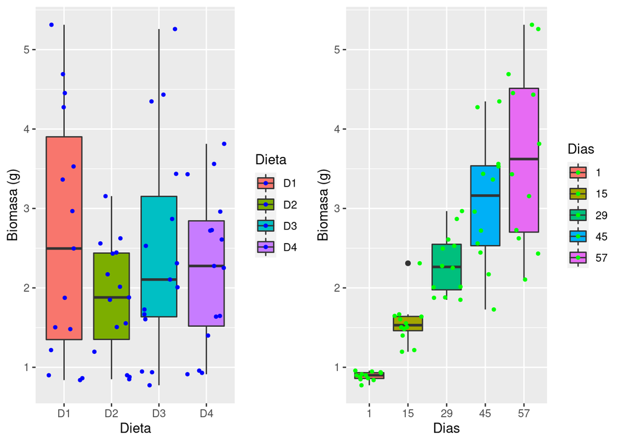

```r
plot3<- ggplot(Growth, aes(x=Dieta, y=Biomasa, fill = Dieta))+
  geom_boxplot()+
  labs(y="Biomasa (g)")+
  geom_jitter(color="blue", size=1)

plot4<-ggplot(Growth, aes(x=Dias, y=Biomasa, fill = Dias))+
  geom_boxplot()+
  labs(y="Biomasa (g)")+
  geom_jitter(color="green", size=1)

grid.arrange(plot3, plot4,ncol=2, nrow =1)
```

A partir del gráfico izquierdo se ve que habría algunas diferencias de medias según los tratamientos (dietas) y que no habría datos potencialmente *outlyers* para remover del análisis. Mientras que el gráfico de la derecha evidencia el fuerte efecto de la variable dias sobre la variable respuesta y la presencia un dato *outlayer* en el muestreo del 9-11-2015 (dia 15).

### Se importa la tabla de longitudes y se arrregla para trabajar con R

```r
Length <- read_excel("Datos pejerrey.xlsx", sheet = 3, na="NA")
head(Length)
```

```
## # A tibble: 6 × 13
##   Fecha      `Tanque 1` `Tanque 2` `Tanque 3` `Tanque 4` `Tanque 5` `Tanque 6`
##   <chr>           <dbl>      <dbl>      <dbl>      <dbl>      <dbl>      <dbl>
## 1 26-10-2015       8.75      15.8        11.7      11.7       16.6        9.99
## 2 26-10-2015       7.12      15.3        12.8       9.52      10.8        9.12
## 3 26-10-2015       8.59      11.0        13.2       9.22      11.8       13.0
## 4 26-10-2015      12.6       15.8        12.4      13.3        8.38      10.2
## 5 26-10-2015      17.4       13.0        13.7      17.9        9.59       8.68
## 6 26-10-2015      11.3        8.02       13.0      17.6       14.3       11.4
## # … with 6 more variables: `Tanque 7` <dbl>, `Tanque 8` <dbl>,
## #   `Tanque 9` <dbl>, `Tanque 10` <dbl>, `Tanque 11` <dbl>, `Tanque 12` <dbl>
```

```r
Length$Fecha<-as.factor(Length$Fecha)
tidy_length<-Length%>%gather("Tanque","Length",2:13)
tidy_length$Tanque<-as.factor(tidy_length$Tanque)
head(tidy_length)
```

```
## # A tibble: 6 × 3
##   Fecha      Tanque   Length
##   <fct>      <fct>     <dbl>
## 1 26-10-2015 Tanque 1   8.75
## 2 26-10-2015 Tanque 1   7.12
## 3 26-10-2015 Tanque 1   8.59
## 4 26-10-2015 Tanque 1  12.6
## 5 26-10-2015 Tanque 1  17.4
## 6 26-10-2015 Tanque 1  11.3
```

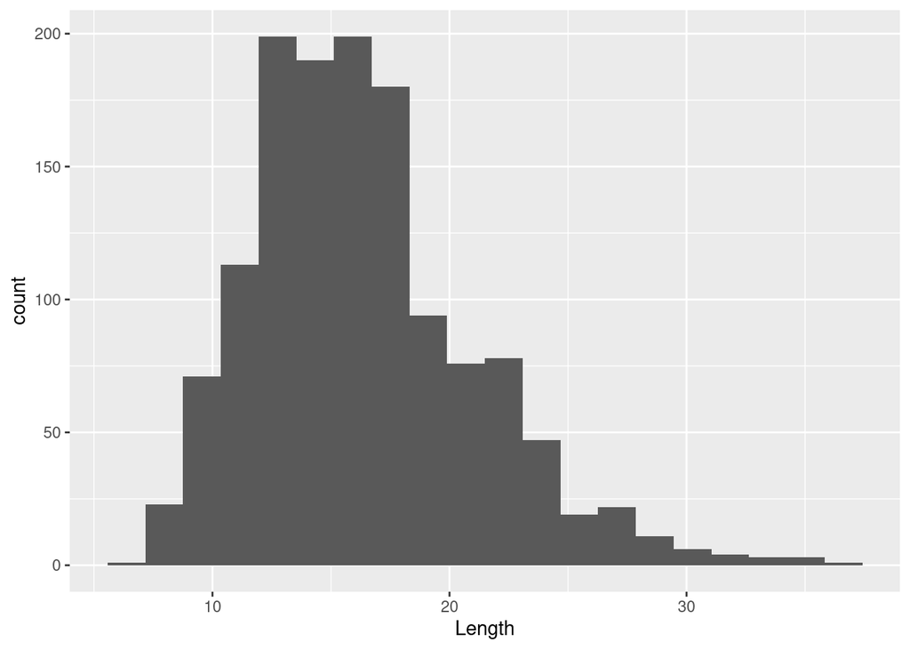

```r
ggplot(tidy_length, aes(Length))+
  geom_histogram (bins = 20)
```

El histograma muestra que los datos están distribuidos en forma asimétrica. Habrá que estudiar los parámetros para determinar si los datos se ajustan a una distribución normal.

```r
table(tidy_length$Tanque, tidy_length$Fecha)
```

```
##
##             21-12-2015 23-11-2015 26-10-2015 9-11-2015 9-12-2015
##   Tanque 1          20         20         26        26        20
##   Tanque 10         20         20         26        26        20
##   Tanque 11         20         20         26        26        20
##   Tanque 12         20         20         26        26        20
##   Tanque 2          20         20         26        26        20
##   Tanque 3          20         20         26        26        20
##   Tanque 4          20         20         26        26        20
##   Tanque 5          20         20         26        26        20
##   Tanque 6          20         20         26        26        20
##   Tanque 7          20         20         26        26        20
##   Tanque 8          20         20         26        26        20
##   Tanque 9          20         20         26        26        20
```

Por lo que surge de esta tabla los datos estan bien balanceados para todos los tanques en cada fecha de muestreo, pero en distintas fechas se tomaron distinto tamaño de muestra.

### Combinación de tablas.

Para poder combinar con la tabla *Growth* se cambian Tanque1, Tanque2…Tanque12 por los números de tanque: 1…12.

```r
tidy_length$Tanque = factor(tidy_length$Tanque, labels = c("1","10", "11","12", 2:9) )
str(tidy_length)
```

```
## tibble [1,344 × 3] (S3: tbl_df/tbl/data.frame)
##  $ Fecha : Factor w/ 5 levels "21-12-2015","23-11-2015",..: 3 3 3 3 3 3 3 3 3 3 ...
##  $ Tanque: Factor w/ 12 levels "1","10","11",..: 1 1 1 1 1 1 1 1 1 1 ...
##  $ Length: num [1:1344] 8.75 7.12 8.59 12.57 17.42 ...
```

```r
levels(tidy_length$Tanque)
```

```
##  [1] "1"  "10" "11" "12" "2"  "3"  "4"  "5"  "6"  "7"  "8"  "9"
```

Luego se asigna la variable Tanque como número para que no se altere el orden y también se cambia la variable Fecha en *date* para poder cálcular una nueva variable Dias.

```r
tidy_length$Tanque<-as.double(tidy_length$Tanque) #lo pongo como numero para que mantenga el orden y no me ponga el 10 en segundo lugar
tidy_length$Fecha<-as.Date(tidy_length$Fecha, "%d-%m-%y")# se transforma character como fecha (date)
```

Luego se obtienen los promedios de la talla para cada tanque y cada fecha.

```r
Length_mean<-tidy_length%>%group_by(Fecha,Tanque) %>%
  summarize(mean_length = mean(Length, na.rm=T))

str(Length_mean)
```

```
## grouped_df [60 × 3] (S3: grouped_df/tbl_df/tbl/data.frame)
##  $ Fecha      : Date[1:60], format: "2020-10-26" "2020-10-26" ...
##  $ Tanque     : num [1:60] 1 2 3 4 5 6 7 8 9 10 ...
##  $ mean_length: num [1:60] 11.6 12.4 13.5 12.5 11.4 ...
##  - attr(*, "groups")= tibble [5 × 2] (S3: tbl_df/tbl/data.frame)
##   ..$ Fecha: Date[1:5], format: "2020-10-26" "2020-11-09" ...
##   ..$ .rows: list<int> [1:5]
##   .. ..$ : int [1:12] 1 2 3 4 5 6 7 8 9 10 ...
##   .. ..$ : int [1:12] 13 14 15 16 17 18 19 20 21 22 ...
##   .. ..$ : int [1:12] 25 26 27 28 29 30 31 32 33 34 ...
##   .. ..$ : int [1:12] 37 38 39 40 41 42 43 44 45 46 ...
##   .. ..$ : int [1:12] 49 50 51 52 53 54 55 56 57 58 ...
##   .. ..@ ptype: int(0)
##   ..- attr(*, ".drop")= logi TRUE
```

Se juntan las medias de la talla con la tabla growth utilizando el comando cbind()

```r
Tabla_crecimiento<- cbind(Growth,Length_mean$mean_length)
```

### Análisis exploratorio de la variable *mean_length*

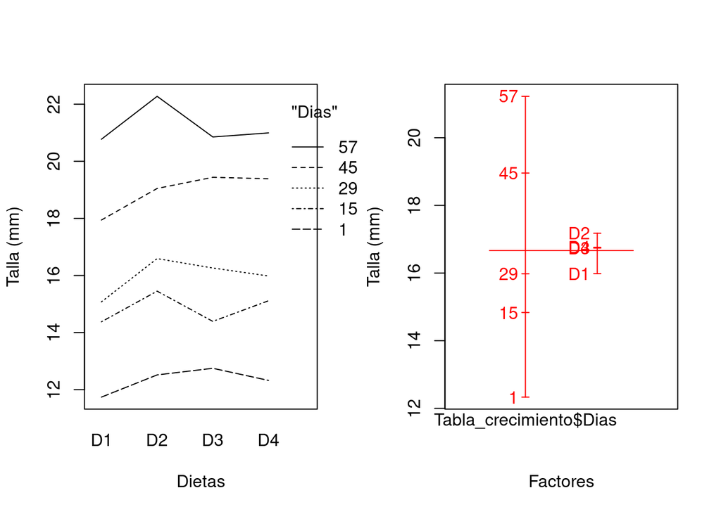

```r
par(mfrow = c(1, 2))

interaction.plot(Tabla_crecimiento$Dieta, Tabla_crecimiento$Dias, Tabla_crecimiento$`Length_mean$mean_length`, fun=mean, trace.label = deparse1("Dias"), xlab="Dietas", ylab="Talla (mm)")

plot.design(Tabla_crecimiento$`Length_mean$mean_length` ~ Tabla_crecimiento$Dias + Tabla_crecimiento$Dieta, col="red",ylab = "Talla (mm)", xlab = "Factores")
```

```r
par(mfrow = c(1, 1))
```

Del mismo modo que se vio para la Biomasa, la talla se ve influenciada principalmente por los dias de muestreo, pero también por la dieta.

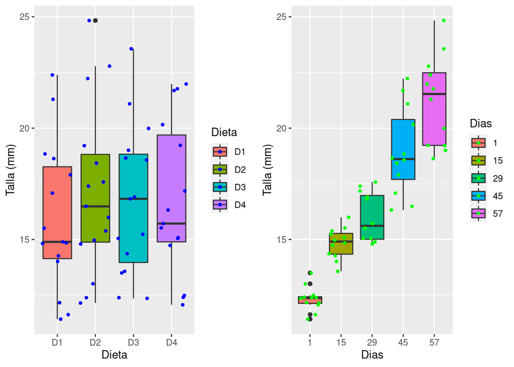

```r
plot7<- ggplot(Tabla_crecimiento, aes(x=Dieta, y=`Length_mean$mean_length`, fill = Dieta))+
  geom_boxplot()+
  labs(y="Talla (mm)")+
  geom_jitter(color="blue", size=1)

plot8<-ggplot(Tabla_crecimiento, aes(x=Dias, y=`Length_mean$mean_length`, fill = Dias))+
  geom_boxplot()+
  labs(y="Talla (mm)")+
  geom_jitter(color="green", size=1)

grid.arrange(plot7, plot8,ncol=2, nrow =1)
```

Los gráficos muestan que habría efecto sobre la talla tanto de las dietas como del tiempo de muestreo. También se ve que habría varios valores atípicos en las tallas de los peces muestreados el primer dia del ensayo.

### Tabla resumen

Finalmente se realiza una tabla resumen mostrando las medias y los desvios de Biomasa y Talla para cada una de las dietas y en cada uno de los muestreos.

```r
Tabla_resumen<-Tabla_crecimiento%>%group_by(Dias, Dieta)%>%
  summarize("n"=n(),"Peso promedio"=mean(Biomasa),"Peso DE"=sd(Biomasa),"Largo promedio"=mean(`Length_mean$mean_length`),"largo DE"=sd(`Length_mean$mean_length`))

pander::pander(Tabla_resumen, caption = "Efecto de la dieta sobre crecimiento")
```

Efecto de la dieta sobre crecimiento

| Dias | Dieta | n | Peso promedio | Peso DE | Largo promedio | largo DE |
| --- | --- | --- | --- | --- | --- | --- |
| 1 | D1 | 3 | 0.8673 | 0.03073 | 11.74 | 0.3814 |
| 1 | D2 | 3 | 0.8763 | 0.02511 | 12.52 | 0.4451 |
| 1 | D3 | 3 | 0.8863 | 0.09739 | 12.75 | 0.6498 |
| 1 | D4 | 3 | 0.9337 | 0.02272 | 12.32 | 0.2239 |
| 15 | D1 | 3 | 1.401 | 0.1595 | 14.38 | 0.426 |
| 15 | D2 | 3 | 1.419 | 0.1945 | 15.45 | 0.5155 |
| 15 | D3 | 3 | 1.861 | 0.3904 | 14.39 | 0.8318 |
| 15 | D4 | 3 | 1.562 | 0.1401 | 15.11 | 0.3928 |
| 29 | D1 | 3 | 2.446 | 0.5477 | 15.08 | 0.3766 |
| 29 | D2 | 3 | 1.915 | 0.08732 | 16.59 | 1.557 |
| 29 | D3 | 3 | 2.468 | 0.4332 | 16.26 | 1.051 |
| 29 | D4 | 3 | 2.379 | 0.1995 | 15.98 | 1.089 |
| 45 | D1 | 3 | 3.723 | 0.4854 | 17.94 | 0.8789 |
| 45 | D2 | 3 | 2.392 | 0.1998 | 19.05 | 2.919 |
| 45 | D3 | 3 | 3.171 | 1.33 | 19.44 | 1.433 |
| 45 | D4 | 3 | 3.081 | 0.4328 | 19.39 | 2.763 |
| 57 | D1 | 3 | 4.819 | 0.4441 | 20.77 | 1.933 |
| 57 | D2 | 3 | 2.737 | 0.3745 | 22.28 | 2.843 |
| 57 | D3 | 3 | 3.932 | 1.636 | 20.85 | 2.398 |
| 57 | D4 | 3 | 3.324 | 0.5508 | 20.99 | 1.532 |